# The chemical logic of glycolysis

Sergio Martínez Cuesta, EMBL-EBI  
24th June 2015

### Aim

“Just as methods for comparing **protein and DNA sequences and structures** have improved our basic understanding of evolution, a method allowing quantitative comparison of **enzyme reactions** should provide a firm foundation from which to explore the evolution of enzyme function and to facilitate the design of new enzymes.” (Rahman et al., 2014)

**Learn by example:** Visualise chemical similarities between enzymes reactions in glycolysis

Use R to explore data, run PCA, clustering analysis and plot heatmaps

### Glycolysis

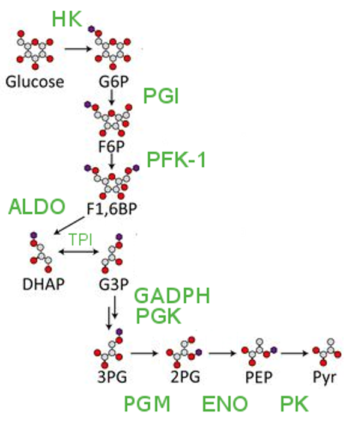

### Overview

- Data input
- Explore data
- Principal component analysis
- Clustering analysis
- Heatmaps

### Set working directory!

```r
> getwd()
> setwd("~/Desktop/glycolysis")
```

### Data input

```r
> data<-read.csv("data/bc.csv", header=TRUE, row.names=1, sep="\t", check.names=FALSE)
```

**bc.csv** contains the frequency counts of chemical bond changes of the 10 reactions in glycolysis

**header=TRUE** and **row.names=1** allow the first row and column to be the column and row names, **sep=“\t”** indicates that bc.csv is tab-separated and **check.names=FALSE** disables the check of variable names

### Explore data

```r
> data
```

Type of object and dimensions:

```r
> class(data)
```

```r
> dim(data)
```

Types of bond changes and glycolysis enzyme IDs:

```r
> colnames(data)
```

```r
> rownames(data)
```

### Barplot

Which glycolytic enzyme catalyses more bond changes?

```r
> freqs_bc<-sort(rowSums(data), decreasing=TRUE)
> barplot(freqs_bc, col="white", ylab="Frequency of bond changes", xlab="Enzyme name")
```

Which bond changes are more common in glycolysis?

```r
> freqs_enz<-sort(colSums(data), decreasing=TRUE)
> barplot(freqs_enz, col="white", ylab="Frequency of bond changes", xlab="Type of bond change")
```

What is the average number of bond changes by glycolytic reaction?

[figure not shown]

[figure not shown]

```r
> mean(rowSums(data))
```

[output not shown]

### How can we represent chemical distance between reactions?

```r
> print(data)
```

|  | P-O | C-C | C-O | O-H | C-H | C-O<->C=O | C-C<->C=C | C(R/S) |
| --- | --- | --- | --- | --- | --- | --- | --- | --- |
| HK | 2 | 0 | 0 | 2 | 0 | 0 | 0 | 0 |
| PGI | 0 | 0 | 2 | 0 | 2 | 0 | 0 | 1 |
| PFK-1 | 2 | 0 | 0 | 2 | 0 | 0 | 0 | 0 |
| ALDO | 0 | 1 | 1 | 3 | 1 | 2 | 0 | 2 |
| TPI | 0 | 0 | 0 | 2 | 2 | 2 | 0 | 1 |
| GAPDH | 0 | 0 | 1 | 1 | 2 | 0 | 0 | 0 |
| PGK | 2 | 0 | 0 | 2 | 0 | 0 | 0 | 0 |
| PGM | 2 | 0 | 0 | 2 | 0 | 0 | 0 | 0 |
| ENO | 0 | 0 | 1 | 1 | 1 | 0 | 1 | 1 |
| PK | 2 | 0 | 0 | 1 | 1 | 1 | 1 | 0 |

### Principal Component Analysis (PCA)

Method to discover structure in large multidimensional datasets.

```r
> print(head(mtcars)[,1:6])
```

|  | mpg | cyl | disp | hp | drat | wt |
| --- | --- | --- | --- | --- | --- | --- |
| Mazda RX4 | 21.0 | 6 | 160 | 110 | 3.90 | 2.620 |
| Mazda RX4 Wag | 21.0 | 6 | 160 | 110 | 3.90 | 2.875 |
| Datsun 710 | 22.8 | 4 | 108 | 93 | 3.85 | 2.320 |
| Hornet 4 Drive | 21.4 | 6 | 258 | 110 | 3.08 | 3.215 |
| Hornet Sportabout | 18.7 | 8 | 360 | 175 | 3.15 | 3.440 |
| Valiant | 18.1 | 6 | 225 | 105 | 2.76 | 3.460 |

Reduce dimensionality

To find a small number of linear combinations of the variables (bond changes) in order to capture most of the variation in the dataset as a whole.

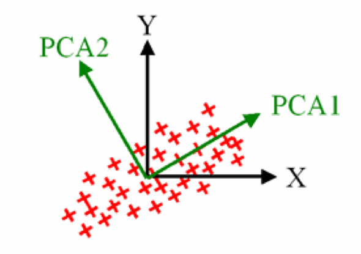

### How can we represent chemical distance between reactions?

```r
> print(data)
```

|  | P-O | C-C | C-O | O-H | C-H | C-O<->C=O | C-C<->C=C | C(R/S) |
| --- | --- | --- | --- | --- | --- | --- | --- | --- |
| HK | 2 | 0 | 0 | 2 | 0 | 0 | 0 | 0 |
| PGI | 0 | 0 | 2 | 0 | 2 | 0 | 0 | 1 |
| PFK-1 | 2 | 0 | 0 | 2 | 0 | 0 | 0 | 0 |
| ALDO | 0 | 1 | 1 | 3 | 1 | 2 | 0 | 2 |
| TPI | 0 | 0 | 0 | 2 | 2 | 2 | 0 | 1 |
| GAPDH | 0 | 0 | 1 | 1 | 2 | 0 | 0 | 0 |
| PGK | 2 | 0 | 0 | 2 | 0 | 0 | 0 | 0 |
| PGM | 2 | 0 | 0 | 2 | 0 | 0 | 0 | 0 |
| ENO | 0 | 0 | 1 | 1 | 1 | 0 | 1 | 1 |
| PK | 2 | 0 | 0 | 1 | 1 | 1 | 1 | 0 |

### Principal Component Analysis (PCA)

```r
> fit <- princomp(data)
```

Check variance explained by top components:

```r
> summary(fit)
```

[output not shown]

Plot first two components:

```r
> biplot(fit, main="PCA")
```

How do bond changes relate to PCA components?

```r
> loadings(fit)
```

[output not shown]

How do enzymes relate to PCA components?

[figure not shown]

```r
> fit$scores
```

[output not shown]

### Hierarchical clustering

Group objects with related variables in a tree

E.g. enzyme reactions with similar patterns of bond changes or cars with similar technical features

[figure not shown]

### Chemical distance between glycolysis reactions

For example, HK, PFK-1, PGK and PGM catalyse exactly the same bond changes - they are chemically identical. As a result, they are separated by a distance of 0 bond changes.

```r
> d <- dist(data, method = "manhattan")
> print(d)
```

```
      HK PGI PFK-1 ALDO TPI GAPDH PGK PGM ENO
PGI    9
PFK-1  0   9
ALDO  10   9    10
TPI    7   6     7    5
GAPDH  6   3     6    8   5
PGK    0   9     0   10   7     6
PGM    0   9     0   10   7     6   0
ENO    7   4     7    7   6     3   7   7
PK     4   9     4   10   7     6   4   4   5
```

### Hierarchical clustering

We need the distance matrix in order to perform hierarchical clustering.

```r
> fit <- hclust(d, method="ward")
```

Plot hierarchical tree:

```r
> plot(fit)
```

Define clusters:

```r
> groups <- cutree(fit, k=4)
```

Plot clusters:

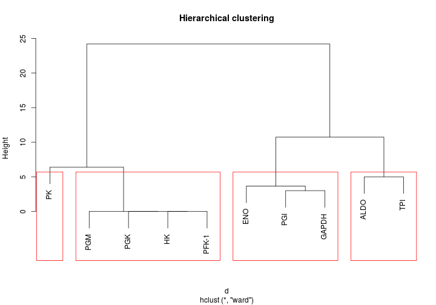

```r
> rect.hclust(fit, k=4, border="red")
```

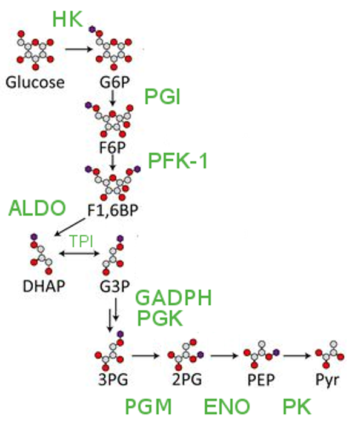

### Heatmaps

Visualise hierarchical clustering

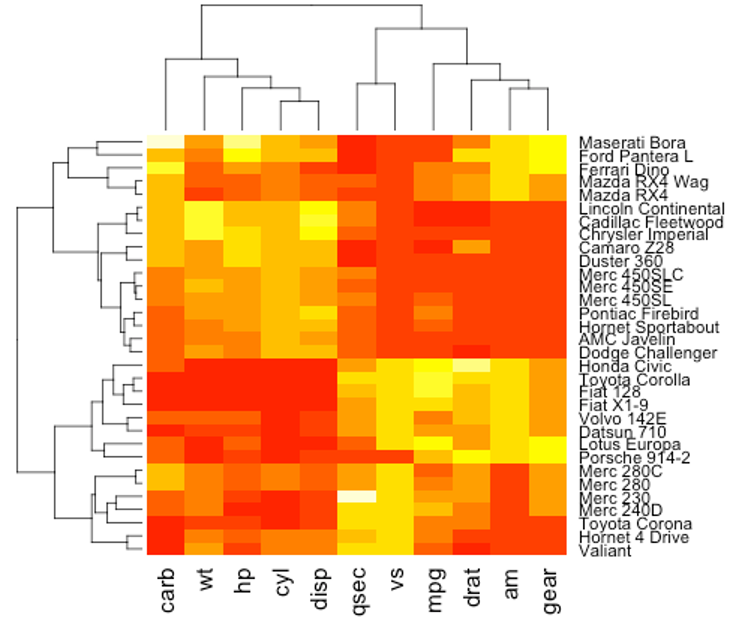

### Heatmaps

Display frequencies in the input matrix using colours

Reactions vs. bond changes:

```r
> heatmap(as.matrix(data))
```

Just reactions:

[figure not shown]

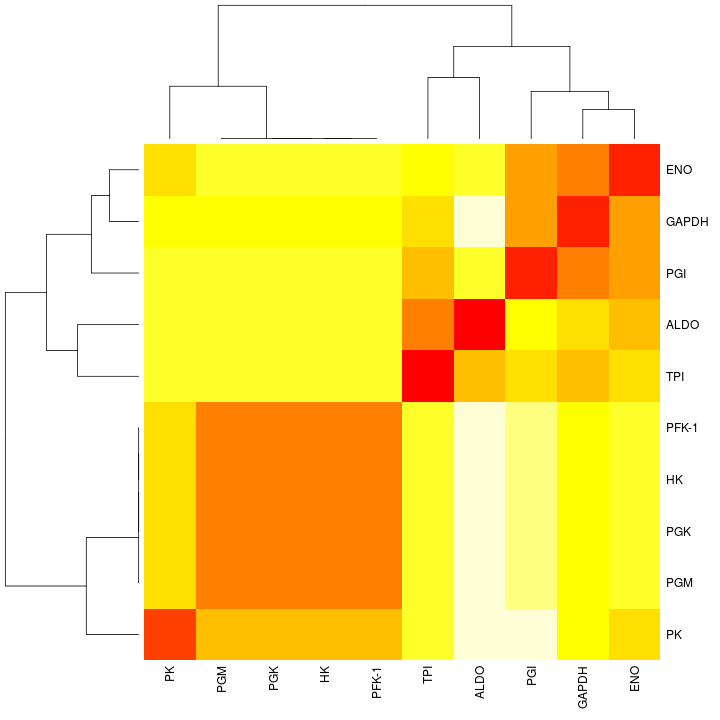

```r
> heatmap(as.matrix(d))
```

### Pretty heatmaps

Install and load pheatmap package:

```r
> install.packages("pheatmap")
> library(pheatmap)
```

Run pheatmap:

```r
> pheatmap(data, fontsize=13, cellwidth = 15, cellheight = 15, color = colorRampPalette(c("white", "red"))(4), clustering_distance_rows=d, legend_breaks=c(0,1,2,3))
```

**fontsize**, **cellwidth** and **cellheight** defines the size of the font and cell, **color** selects four colours from white to red, **clustering_distance_rows** uses the distance matrix calculated previously and **legend_breaks** defines the numbers in the legend.

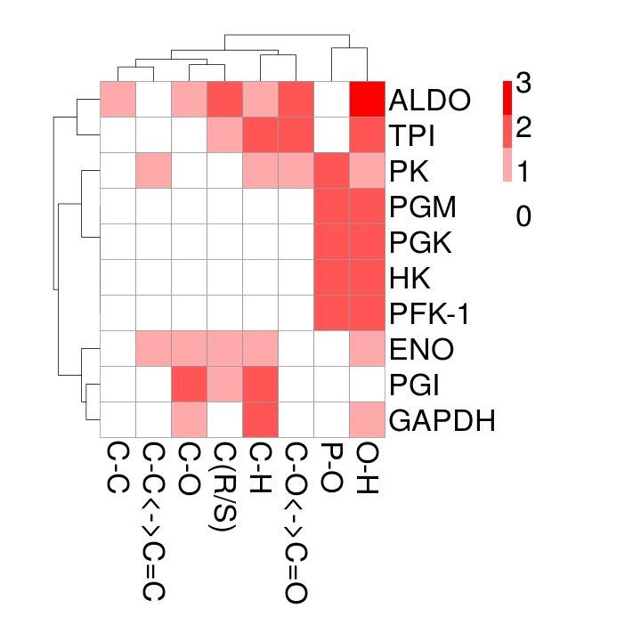

### References

1- Quick-R: http://www.statmethods.net/

2- Crawley, M. J. (2007). The R Book. Chichester, UK: John Wiley & Sons, Ltd. doi:10.1002/9780470515075

3- Husson, F., Lê, S., and Pagès, J. (2011) Exploratory multivariate analysis by example using R, [online] http://books.google.com/books?hl=en&lr=&id=EDnNBQAAQBAJ&oi=fnd&pg=PP1&dq=Exploratory+Multivariate+Analysis+by+Example+Using+R&ots=I4bnnmgPJw&sig=ENW39pnO00fOOSO_F01cQ_Iv-UA (Accessed February 6, 2015).

4- Rahman, S. A., Martínez Cuesta, S., Furnham, N., Holliday, G. L., & Thornton, J. M. (2014). EC-BLAST: a tool to automatically search and compare enzyme reactions. Nature methods, 11(2), 171–174. doi:10.1038/nmeth.2803. url: http://www.ebi.ac.uk/thornton-srv/software/rbl/

5- Keller, M. A., Turchyn, A. V., & Ralser, M. (2014). Non-enzymatic glycolysis and pentose phosphate pathway-like reactions in a plausible Archean ocean. Molecular systems biology, 10, 725. Retrieved from http://www.ncbi.nlm.nih.gov/pubmed/24771084

### Thanks!

scuesta@ebi.ac.uk